# TADPOLE_Survival

Jose Tamez

2023-02-02

# 1 TADPOLE Univariate

### 1.0.1 The run options

```r
TrainFraction <- 0.50;
sig_pvalue <- 0.01
thr <- c(0.05,0.2,0.4,0.6,0.8,0.95);
method  <- c("fast","pearson","spearman","kendall");
type <- c("LM","RLM")
DeOutcome <- c("NoDriven","Driven")
corRankS <- c("FALSE","TRUE")

thr <- thr[4]
method  <- method[1]
type <- type[1]
DeOutcome <- DeOutcome[2]
corRankS <- corRankS[2]


corRank <- corRankS == "TRUE"
```

### 1.0.2 Loading the libraries

```r
library("FRESA.CAD")
library(readxl)
library("whitening")
library("fpc")
library("robust")
op <- par(no.readonly = TRUE)
pander::panderOptions('digits', 3)
pander::panderOptions('table.split.table', 400)
pander::panderOptions('keep.trailing.zeros',TRUE)
```

## 1.1 The data set

```r
TADPOLE_D1_D2 <- read.csv("~/GitHub/BSWiMS/Data/TADPOLE/TADPOLE_D1_D2.csv")
TADPOLE_D1_D2_Dict <- read.csv("~/GitHub/BSWiMS/Data/TADPOLE/TADPOLE_D1_D2_Dict.csv")
TADPOLE_D1_D2_Dict_LR <- as.data.frame(read_excel("~/GitHub/BSWiMS/Data/TADPOLE/TADPOLE_D1_D2_Dict_LR.xlsx",sheet = "LeftRightFeatures"))


rownames(TADPOLE_D1_D2_Dict) <- TADPOLE_D1_D2_Dict$FLDNAME
```

## 1.2 Conditioning the data

```r
# mm3 to mm
isVolume <- c("Ventricles","Hippocampus","WholeBrain","Entorhinal","Fusiform","MidTemp","ICV",
              TADPOLE_D1_D2_Dict$FLDNAME[str_detect(TADPOLE_D1_D2_Dict$TEXT,"Volume")]
              )


#TADPOLE_D1_D2[,isVolume] <- apply(TADPOLE_D1_D2[,isVolume],2,'^',(1/3))
TADPOLE_D1_D2[,isVolume] <- TADPOLE_D1_D2[,isVolume]^(1/3)

# mm2 to mm
isArea <- TADPOLE_D1_D2_Dict$FLDNAME[str_detect(TADPOLE_D1_D2_Dict$TEXT,"Area")]
TADPOLE_D1_D2[,isArea] <- sqrt(TADPOLE_D1_D2[,isArea])

# Get only cross sectional measurements
FreeSurfersetCross <- str_detect(colnames(TADPOLE_D1_D2),"UCSFFSX")

# The subset of baseline measurements
baselineTadpole <- subset(TADPOLE_D1_D2,VISCODE=="bl")
table(baselineTadpole$DX)
```

```
                   Dementia Dementia to MCI             MCI MCI to Dementia
          7             336               1             864               5
  MCI to NL              NL       NL to MCI
          2             521               1
```

```r
table(baselineTadpole$DX_bl)
```

AD CN EMCI LMCI SMC 342 417 310 562 106

```r
rownames(baselineTadpole) <- baselineTadpole$PTID


validBaselineTadpole <- cbind(DX=baselineTadpole$DX_bl,
                                 AGE=baselineTadpole$AGE,
                                 Gender=1*(baselineTadpole$PTGENDER=="Female"),
                                 ADAS11=baselineTadpole$ADAS11,
                                 ADAS13=baselineTadpole$ADAS13,
                                 MMSE=baselineTadpole$MMSE,
                                 RAVLT_immediate=baselineTadpole$RAVLT_immediate,
                                 RAVLT_learning=baselineTadpole$RAVLT_learning,
                                 RAVLT_forgetting=baselineTadpole$RAVLT_forgetting,
                                 RAVLT_perc_forgetting=baselineTadpole$RAVLT_perc_forgetting,
                                 FAQ=baselineTadpole$FAQ,
                                 Ventricles=baselineTadpole$Ventricles,
                                 Hippocampus=baselineTadpole$Hippocampus,
                                 WholeBrain=baselineTadpole$WholeBrain,
                                 Entorhinal=baselineTadpole$Entorhinal,
                                 Fusiform=baselineTadpole$Fusiform,
                                 MidTemp=baselineTadpole$MidTemp,
                                 ICV=baselineTadpole$ICV,
                                 baselineTadpole[,FreeSurfersetCross])


LeftFields <- TADPOLE_D1_D2_Dict_LR$LFN
names(LeftFields) <- LeftFields
LeftFields <- LeftFields[LeftFields %in% colnames(validBaselineTadpole)]
RightFields <- TADPOLE_D1_D2_Dict_LR$RFN
names(RightFields) <- RightFields
RightFields <- RightFields[RightFields %in% colnames(validBaselineTadpole)]

## Normalize to ICV
validBaselineTadpole$Ventricles=validBaselineTadpole$Ventricles/validBaselineTadpole$ICV
validBaselineTadpole$Hippocampus=validBaselineTadpole$Hippocampus/validBaselineTadpole$ICV
validBaselineTadpole$WholeBrain=validBaselineTadpole$WholeBrain/validBaselineTadpole$ICV
validBaselineTadpole$Entorhinal=validBaselineTadpole$Entorhinal/validBaselineTadpole$ICV
validBaselineTadpole$Fusiform=validBaselineTadpole$Fusiform/validBaselineTadpole$ICV
validBaselineTadpole$MidTemp=validBaselineTadpole$MidTemp/validBaselineTadpole$ICV

leftData <- validBaselineTadpole[,LeftFields]/validBaselineTadpole$ICV
RightData <- validBaselineTadpole[,RightFields]/validBaselineTadpole$ICV

## get mean and relative difference
meanLeftRight <- (leftData + RightData)/2
difLeftRight <- abs(leftData - RightData)
reldifLeftRight <- difLeftRight/meanLeftRight
colnames(meanLeftRight) <- paste("M",colnames(meanLeftRight),sep="_")
colnames(difLeftRight) <- paste("D",colnames(difLeftRight),sep="_")
colnames(reldifLeftRight) <- paste("RD",colnames(reldifLeftRight),sep="_")


validBaselineTadpole <- validBaselineTadpole[,!(colnames(validBaselineTadpole) %in%
                                               c(LeftFields,RightFields))]
#validBaselineTadpole <- cbind(validBaselineTadpole,meanLeftRight,difLeftRight,reldifLeftRight)
validBaselineTadpole <- cbind(validBaselineTadpole,meanLeftRight,difLeftRight)

## Remove columns with too many NA more than %15 of NA
nacount <- apply(is.na(validBaselineTadpole),2,sum)/nrow(validBaselineTadpole) < 0.15
diagnose <- validBaselineTadpole$DX
pander::pander(table(diagnose))
```

| AD | CN | EMCI | LMCI | SMC |
| --- | --- | --- | --- | --- |
| 342 | 417 | 310 | 562 | 106 |

```r
validBaselineTadpole <- validBaselineTadpole[,nacount]
## Remove character columns
ischar <- sapply(validBaselineTadpole,class) == "character"
validBaselineTadpole <- validBaselineTadpole[,!ischar]
## Place back diagnose
validBaselineTadpole$DX <- diagnose


validBaselineTadpole <- validBaselineTadpole[complete.cases(validBaselineTadpole),]
ischar <- sapply(validBaselineTadpole,class) == "character"
validBaselineTadpole[,!ischar] <- sapply(validBaselineTadpole[,!ischar],as.numeric)

colnames(validBaselineTadpole) <- str_remove_all(colnames(validBaselineTadpole),"_UCSFFSX_11_02_15_UCSFFSX51_08_01_16")
colnames(validBaselineTadpole) <- str_replace_all(colnames(validBaselineTadpole)," ","_")
validBaselineTadpole$LONISID <- NULL
validBaselineTadpole$IMAGEUID <- NULL
validBaselineTadpole$LONIUID <- NULL

diagnose <- as.character(validBaselineTadpole$DX)
validBaselineTadpole$DX <- diagnose
pander::pander(table(validBaselineTadpole$DX))
```

| AD | CN | EMCI | LMCI | SMC |
| --- | --- | --- | --- | --- |
| 245 | 359 | 272 | 444 | 93 |

```r
validBaselineTadpole[validBaselineTadpole$DX %in% c("EMCI","LMCI"),"DX"] <- "MCI"
validBaselineTadpole[validBaselineTadpole$DX %in% c("CN","SMC"),"DX"] <- "NL"

pander::pander(table(validBaselineTadpole$DX))
```

| AD | MCI | NL |
| --- | --- | --- |
| 245 | 716 | 452 |

## 1.3 Get the Time To Event on MCI Subjects

```r
subjectsID <- rownames(validBaselineTadpole)
visitsID <- unique(TADPOLE_D1_D2$VISCODE)
baseDx <- TADPOLE_D1_D2[TADPOLE_D1_D2$VISCODE=="bl",c("PTID","DX","EXAMDATE")]
rownames(baseDx) <- baseDx$PTID
baseDx <- baseDx[subjectsID,]
lastDx <- baseDx
toDementia <- baseDx
table(lastDx$DX)
```

```
   Dementia Dementia to MCI             MCI MCI to Dementia       MCI to NL
        244               1             711               2               2
         NL       NL to MCI
        452               1
```

```r
hasDementia <- lastDx$PTID[str_detect(lastDx$DX,"Dementia")]


for (vid in visitsID)
{
  DxValue <- TADPOLE_D1_D2[TADPOLE_D1_D2$VISCODE==vid,c("PTID","DX","EXAMDATE")]
  rownames(DxValue) <- DxValue$PTID
  DxValue <- DxValue[DxValue$PTID %in% subjectsID,]
  noDX <- DxValue$PTID[nchar(DxValue$DX) < 1]
  print(length(noDX))
  DxValue[noDX,] <- lastDx[noDX,]
  inLast <- lastDx$PTID[lastDx$PTID %in% DxValue$PTID]
  print(length(inLast))
  lastDx[inLast,] <- DxValue[inLast,]
  noDementia <- !(toDementia$PTID %in% hasDementia)
  toDementia[noDementia,] <- lastDx[noDementia,]
  hasDementia <- unique(c(hasDementia,lastDx$PTID[str_detect(lastDx$DX,"Dementia")]))
}
```

```r
table(lastDx$DX)
```

```
   Dementia Dementia to MCI             MCI MCI to Dementia       MCI to NL
        428               2             463              80               7
         NL  NL to Dementia       NL to MCI
        406               1              26
```

```r
baseMCI <-baseDx$PTID[baseDx$DX == "MCI"]
lastDementia <- lastDx$PTID[str_detect(lastDx$DX,"Dementia")]
lastDementia2 <- toDementia$PTID[str_detect(toDementia$DX,"Dementia")]
lastNL <- lastDx$PTID[str_detect(lastDx$DX,"NL")]

MCIatBaseline <- baseDx[baseMCI,]
MCIatEvent <- toDementia[baseMCI,]
MCIatLast <- lastDx[baseMCI,]

MCIconverters <- MCIatBaseline[baseMCI %in% lastDementia,]
MCI_No_converters <- MCIatBaseline[!(baseMCI %in% MCIconverters$PTID),]
MCIconverters$TimeToEvent <- (as.Date(toDementia[MCIconverters$PTID,"EXAMDATE"])
                                   - as.Date(MCIconverters$EXAMDATE))

sum(MCIconverters$TimeToEvent ==0)
```

[1] 0

```r
MCIconverters$AtEventDX <- MCIatEvent[MCIconverters$PTID,"DX"]
MCIconverters$LastDX <- MCIatLast[MCIconverters$PTID,"DX"]

MCI_No_converters$TimeToEvent <- (as.Date(lastDx[MCI_No_converters$PTID,"EXAMDATE"])
                                   - as.Date(MCI_No_converters$EXAMDATE))

MCI_No_converters$LastDX <- MCIatLast[MCI_No_converters$PTID,"DX"]

MCI_No_converters <- subset(MCI_No_converters,TimeToEvent > 0)
```

# 2 Prognosis MCI to AD Conversion

## 2.1 the set

```r
MCIPrognosisIDs <- c(MCIconverters$PTID,MCI_No_converters$PTID)

TADPOLECrossMRI <- validBaselineTadpole[MCIPrognosisIDs,]
table(TADPOLECrossMRI$DX)
```

MCI 680

```r
TADPOLECrossMRI$DX <- NULL
TADPOLECrossMRI$status <- 1*(rownames(TADPOLECrossMRI) %in% MCIconverters$PTID)
table(TADPOLECrossMRI$status)
```

0 1 436 244

#### 2.1.0.1 Analysis parameters

```r
dataframe <- TADPOLECrossMRI
outcome <- "status"
```

```r
pander::pander(c(rows=nrow(dataframe),col=ncol(dataframe)-1))
```

| rows | col |
| --- | --- |
| 680 | 327 |

```r
pander::pander(table(dataframe[,outcome]))
```

| 0 | 1 |
| --- | --- |
| 436 | 244 |

```r
varlist <- colnames(dataframe)
varlist <- varlist[varlist != outcome]
varlist <- as.data.frame(cbind(name=varlist,desc=varlist))
```

## 2.2 Univariate

```r
univariate_columns <- c("caseMean","caseStd","controlMean","controlStd","controlKSP","ROCAUC","WilcoxRes.p","FRes.p")
univar <- uniRankVar(varlist,
               paste(outcome,"~1"),
               outcome,
               dataframe,
               categorizationType = "Raw",
               type = "LOGIT",
               rankingTest = "AUC",
                cateGroups = c(0.1, 0.9),
                raw.dataFrame = NULL,
                description = ".",
                uniType = "Binary")
```

100 : M_ST24SA 200 : D_ST49TA 300 : D_ST47CV

```r
pander::pander(univar$orderframe[1:20,univariate_columns])
```

|  | caseMean | caseStd | controlMean | controlStd | controlKSP | ROCAUC | WilcoxRes.p | FRes.p |
| --- | --- | --- | --- | --- | --- | --- | --- | --- |
| **ADAS13** | 20.7611 | 6.16923 | 14.0091 | 5.78970 | 0.03549 | 0.788 | 1.26e-35 | 0 |
| **ADAS11** | 12.8635 | 4.56128 | 8.7155 | 3.84978 | 0.00264 | 0.761 | 2.80e-31 | 0 |
| **FAQ** | 5.4631 | 4.90262 | 1.9266 | 2.98257 | 0.00000 | 0.756 | 8.02e-32 | 0 |
| **M_ST40CV** | 0.1799 | 0.00875 | 0.1875 | 0.00763 | 0.28199 | 0.750 | 2.50e-28 | 0 |
| **M_ST29SV** | 0.1253 | 0.00708 | 0.1321 | 0.00750 | 0.58088 | 0.745 | 1.38e-25 | 0 |
| **M_ST12SV** | 0.0913 | 0.00535 | 0.0962 | 0.00550 | 0.50030 | 0.744 | 2.46e-26 | 0 |
| **Hippocampus** | 0.1582 | 0.00886 | 0.1664 | 0.00945 | 0.44340 | 0.737 | 4.57e-24 | 0 |
| **RAVLT_immediate** | 29.0205 | 7.69236 | 37.2798 | 10.92838 | 0.04406 | 0.728 | 6.44e-22 | 0 |
| **M_ST24CV** | 0.0996 | 0.00800 | 0.1059 | 0.00706 | 0.04673 | 0.727 | 4.47e-24 | 0 |
| **M_ST31CV** | 0.1910 | 0.00945 | 0.1986 | 0.00902 | 0.94566 | 0.717 | 1.31e-21 | 0 |
| **M_ST24TA** | 0.0263 | 0.00420 | 0.0295 | 0.00376 | 0.06170 | 0.717 | 2.38e-21 | 0 |
| **M_ST13TA** | 0.0192 | 0.00193 | 0.0206 | 0.00177 | 0.43048 | 0.715 | 2.80e-21 | 0 |
| **WholeBrain** | 0.8651 | 0.02013 | 0.8817 | 0.02130 | 0.22041 | 0.715 | 4.57e-20 | 0 |
| **M_ST26CV** | 0.1738 | 0.00843 | 0.1805 | 0.00817 | 0.90562 | 0.712 | 1.36e-20 | 0 |
| **M_ST32CV** | 0.1786 | 0.00875 | 0.1853 | 0.00798 | 0.60250 | 0.711 | 3.55e-21 | 0 |
| **M_ST58CV** | 0.1826 | 0.00814 | 0.1884 | 0.00753 | 0.34556 | 0.707 | 3.68e-20 | 0 |
| **M_ST52TA** | 0.0179 | 0.00171 | 0.0191 | 0.00166 | 0.06529 | 0.707 | 1.69e-19 | 0 |
| **M_ST40TA** | 0.0224 | 0.00215 | 0.0239 | 0.00174 | 0.44247 | 0.703 | 4.02e-20 | 0 |
| **M_ST31TA** | 0.0187 | 0.00185 | 0.0201 | 0.00171 | 0.26927 | 0.703 | 3.04e-19 | 0 |
| **M_ST58TA** | 0.0209 | 0.00202 | 0.0223 | 0.00185 | 0.19465 | 0.702 | 9.58e-19 | 0 |

```r
topfiveOrg <- rownames(univar$orderframe[1:5,])
```

## 2.3 Decorrelation Analysis

```r
DEdataframe <- IDeA(dataframe,thr=0.80,verbose = TRUE)
```

Included: 258 , Uni p: 0.008990399 , Uncorrelated Base: 220 , Outcome-Driven Size: 0 , Base Size: 220

1 <R=1.000,w= 1,N= 6>, Top: 3( 1 )1 : 3 : 0.975,<|>Tot Used: 6 , Added: 3 , Zero Std: 0 , Max Cor: 0.952

2 <R=0.952,w= 1,N= 6>, Top: 1( 1 )1 : 1 : 0.951,<|>Tot Used: 8 , Added: 1 , Zero Std: 0 , Max Cor: 0.909

3 <R=0.909,w= 2,N= 2>, Top: 1( 1 )1 : 1 : 0.904,<|>Tot Used: 10 , Added: 1 , Zero Std: 0 , Max Cor: 0.901

4 <R=0.901,w= 3,N= 17>, Top: 7( 2 )1 : 7 : 0.850,<|>Tot Used: 24 , Added: 8 , Zero Std: 0 , Max Cor: 0.847

5 <R=0.847,w= 3,N= 17>, Top: 6( 1 )1 : 6 : 0.824,<|>Tot Used: 34 , Added: 7 , Zero Std: 0 , Max Cor: 0.923

6 <R=0.923,w= 3,N= 17>, Top: 1( 1 )1 : 1 : 0.862,<|>Tot Used: 35 , Added: 1 , Zero Std: 0 , Max Cor: 0.823

7 <R=0.823,w= 4,N= 28>, Top: 14( 1 )1 : 14 : 0.800,<|>Tot Used: 58 , Added: 14 , Zero Std: 0 , Max Cor: 0.939

8 <R=0.939,w= 4,N= 28>, Top: 5( 1 )1 : 5 : 0.820,<|>Tot Used: 63 , Added: 5 , Zero Std: 0 , Max Cor: 0.800

9 <R=0.000,w= 4,N= 28>

[ 9 ], 0.7842174 Decor Dimension: 63 . Cor to Base: 32 , ABase: 26 , Outcome Base: 0

```r
pander::pander(c(Decorrleated_Fraction=sum(str_detect(colnames(DEdataframe),"La_"))/(ncol(DEdataframe)-1)))
```

| Decorrleated_Fraction |
| --- |
| 0.104 |

```r
pander::pander(c(Base_Fraction=sum(str_detect(colnames(DEdataframe),"Ba_"))/(ncol(DEdataframe)-1)))
```

| Base_Fraction |
| --- |
| 0 |

```r
demat <- attr(DEdataframe,"UPSTM")
pander::pander(c(sparse_Fraction=1.0-sum(demat==0)/ncol(demat)/nrow(demat)))
```

| sparse_Fraction |
| --- |
| 0.026 |

```r
varlistDe <-  colnames(DEdataframe)[colnames(DEdataframe) != "class"];
varlistDe <- as.data.frame(cbind(name=varlistDe,desc=varlistDe))
```

### 2.3.1 The heat maps.

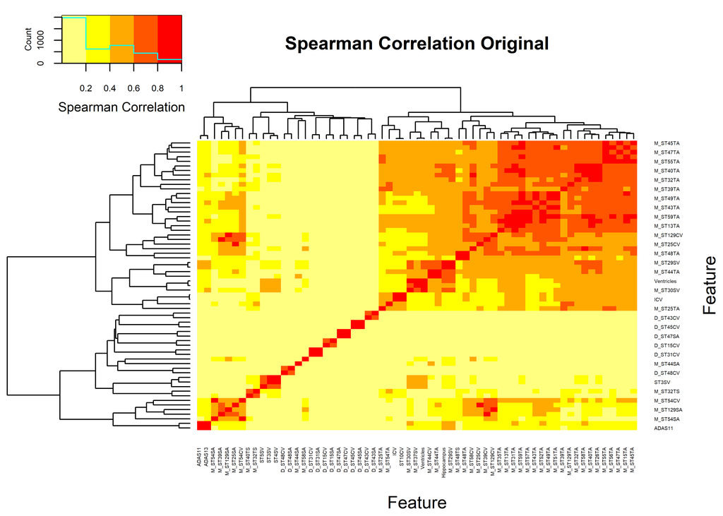

```r
par(cex=0.6,cex.main=0.85,cex.axis=0.7)
cormat <- cor(dataframe[,rownames(demat)],method="spearman")
cormat[is.na(cormat)] <- 0
gplots::heatmap.2(abs(cormat),
                  trace = "none",
#                  scale = "row",
                  mar = c(5,5),
                  col=rev(heat.colors(5)),
                  main = "Spearman Correlation Original",
                  cexRow = 0.35,
                  cexCol = 0.35,
                  key.title=NA,
                  key.xlab="Spearman Correlation",
                  xlab="Feature", ylab="Feature")
```

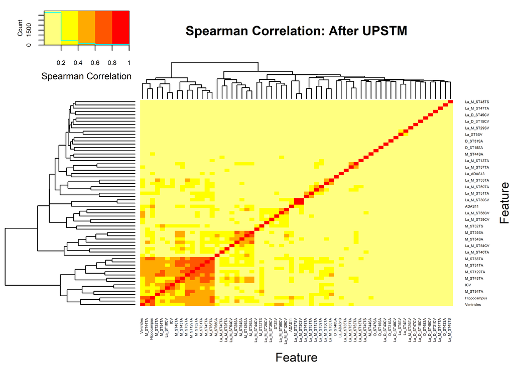

```r
cormat <- cor(DEdataframe[,colnames(demat)],method="spearman")
cormat[is.na(cormat)] <- 0
gplots::heatmap.2(abs(cormat),
                  trace = "none",
#                  scale = "none",
                  mar = c(5,5),
                  col=rev(heat.colors(5)),
                  main = "Spearman Correlation: After UPSTM",
                  cexRow = 0.35,
                  cexCol = 0.35,
                  key.title=NA,
                  key.xlab="Spearman Correlation",
                  xlab="Feature", ylab="Feature")
```

```r
par(op)
```

## 2.4 Univariate Decorrelated

```r
univarDe <- uniRankVar(varlistDe,
              paste(outcome,"~1"),
                outcome,
              DEdataframe,
                categorizationType = "Raw",
                type = "LOGIT",
                rankingTest = "AUC",
                cateGroups = c(0.1, 0.9),
                raw.dataFrame = NULL,
                description = ".",
                uniType = "Binary")
```

100 : M_ST24SA 200 : D_ST49TA 300 : La_D_ST47CV

```r
pander::pander(univarDe$orderframe[1:20,univariate_columns])
```

[output not shown]

### 2.4.1 Comparing Decorrelation vs Original

```r
pthr <- 0.20/(ncol(dataframe)-1)

topDecorNames <- rownames(univarDe$orderframe[univarDe$orderframe$FRes.p<pthr,])
topDecorNames <- unique(c(topDecorNames,rownames(univarDe$orderframe[1:5,])))

#topDecorNames <- rownames(univarDe$orderframe[univarDe$orderframe$FRes.p<1.0e-5,])
dc <- getLatentCoefficients(DEdataframe)
### 2a Get only the ones that in the top features
deNames_in_dc <- topDecorNames[topDecorNames %in% names(dc)]
selectedlist <- dc[deNames_in_dc]
theDeFormulas <- selectedlist

rawuniv <- univariate_Wilcoxon(dataframe,outcome,limit=-1)
deuniv <- univariate_Wilcoxon(DEdataframe,outcome,limit=-1)
matsize <- (ncol(dataframe)-1)^2
nocorrelated <- ncol(dataframe) - 1 - ncol(demat)
pander::pander(c(sparse_Fraction=(sum(demat != 0) + nocorrelated)/matsize))
```

| sparse_Fraction |
| --- |
| 0.00343 |

```r
pander::pander(c(raw=length(rawuniv),decor=length(deuniv)))
```

| raw | decor |
| --- | --- |
| 182 | 165 |

```r
pander::pander(c(Number_Latent=length(dc)))
```

| Number_Latent |
| --- |
| 34 |

```r
pander::pander(c(meanSize=mean(sapply(dc,length))))
```

| meanSize |
| --- |
| 2.18 |

## 2.5 CV ROC Analysis

```r
par(op)
par(mfrow=c(1,2),cex=0.9)
fraction <-0.80
repetitions <- 100

fcout <- round(fraction*nrow(dataframe)/15+1.0)
pander::pander(c(NumberofFeatures=fcout))
```

| NumberofFeatures |
| --- |
| 37 |

```r
cvRaw <- randomCV(dataframe,
                outcome,
                fittingFunction= filteredFit,
                classSamplingType = "Pro",
                trainFraction = fraction,
                repetitions = repetitions,
#                fitmethod=  glm,
                fitmethod=  KNN_method,
                filtermethod=mRMR.classic_FRESA,
                filtermethod.control=list(feature_count= fcout),
#                family="binomial"
)
```

……….10 Tested: 615 Avg. Selected: 37 Min Tests: 1 Max Tests: 6 Mean Tests: 2.227642 . MAD: 0.3131196

……….20 Tested: 673 Avg. Selected: 37 Min Tests: 1 Max Tests: 10 Mean Tests: 4.071322 . MAD: 0.3161106

……….30 Tested: 680 Avg. Selected: 37 Min Tests: 1 Max Tests: 12 Mean Tests: 6.044118 . MAD: 0.3153349

……….40 Tested: 680 Avg. Selected: 37 Min Tests: 2 Max Tests: 16 Mean Tests: 8.058824 . MAD: 0.3149712

……….50 Tested: 680 Avg. Selected: 37 Min Tests: 3 Max Tests: 19 Mean Tests: 10.07353 . MAD: 0.3142627

……….60 Tested: 680 Avg. Selected: 37 Min Tests: 4 Max Tests: 23 Mean Tests: 12.08824 . MAD: 0.3148128

……….70 Tested: 680 Avg. Selected: 37 Min Tests: 5 Max Tests: 25 Mean Tests: 14.10294 . MAD: 0.3140068

……….80 Tested: 680 Avg. Selected: 37 Min Tests: 6 Max Tests: 26 Mean Tests: 16.11765 . MAD: 0.3146324

……….90 Tested: 680 Avg. Selected: 37 Min Tests: 8 Max Tests: 29 Mean Tests: 18.13235 . MAD: 0.3150531

……….100 Tested: 680 Avg. Selected: 37 Min Tests: 10 Max Tests: 33 Mean Tests: 20.14706 . MAD: 0.3146216

```r
bpraw <- predictionStats_binary(cvRaw$medianTest,"RAW",cex=0.75)
```

RAW

```r
pander::pander(bpraw$CM.analysis$tab)
```

|  | Outcome + | Outcome - | Total |
| --- | --- | --- | --- |
| **Test +** | 139 | 57 | 196 |
| **Test -** | 105 | 379 | 484 |
| **Total** | 244 | 436 | 680 |

```r
pander::pander(bpraw$accc)
```

| est | lower | upper |
| --- | --- | --- |
| 0.762 | 0.728 | 0.793 |

```r
pander::pander(bpraw$aucs)
```

| est | lower | upper |
| --- | --- | --- |
| 0.835 | 0.804 | 0.865 |

```r
pander::pander(bpraw$berror)
```

| 50% | 2.5% | 97.5% |
| --- | --- | --- |
| 0.28 | 0.245 | 0.314 |

```r
cvDe <- randomCV(DEdataframe,
                outcome,
                fittingFunction= filteredFit,
                trainSampleSets= cvRaw$trainSamplesSets,
#                fitmethod=  glm,
                fitmethod=  KNN_method,
                filtermethod=mRMR.classic_FRESA,
                filtermethod.control=list(feature_count= fcout),
#                family="binomial"
)
```

……….10 Tested: 615 Avg. Selected: 37 Min Tests: 1 Max Tests: 6 Mean Tests: 2.227642 . MAD: 0.3190161

……….20 Tested: 673 Avg. Selected: 37 Min Tests: 1 Max Tests: 10 Mean Tests: 4.071322 . MAD: 0.3216758

……….30 Tested: 680 Avg. Selected: 37 Min Tests: 1 Max Tests: 12 Mean Tests: 6.044118 . MAD: 0.3211227

……….40 Tested: 680 Avg. Selected: 37 Min Tests: 2 Max Tests: 16 Mean Tests: 8.058824 . MAD: 0.3201657

……….50 Tested: 680 Avg. Selected: 37 Min Tests: 3 Max Tests: 19 Mean Tests: 10.07353 . MAD: 0.3204131

……….60 Tested: 680 Avg. Selected: 37 Min Tests: 4 Max Tests: 23 Mean Tests: 12.08824 . MAD: 0.3213216

……….70 Tested: 680 Avg. Selected: 37 Min Tests: 5 Max Tests: 25 Mean Tests: 14.10294 . MAD: 0.3213517

……….80 Tested: 680 Avg. Selected: 37 Min Tests: 6 Max Tests: 26 Mean Tests: 16.11765 . MAD: 0.3214061

……….90 Tested: 680 Avg. Selected: 37 Min Tests: 8 Max Tests: 29 Mean Tests: 18.13235 . MAD: 0.3194572

……….100 Tested: 680 Avg. Selected: 37 Min Tests: 10 Max Tests: 33 Mean Tests: 20.14706 . MAD: 0.3182687

```r
bpDecor <- predictionStats_binary(cvDe$medianTest,"Decorrelated",cex=0.75)
```

Decorrelated

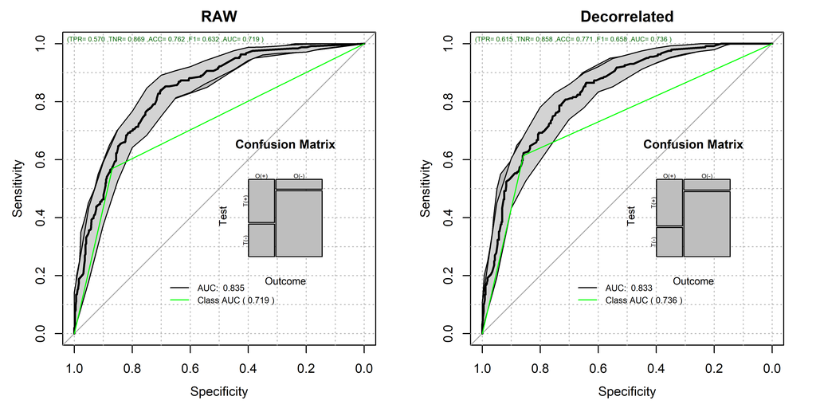

```r
par(op)

pander::pander(bpDecor$CM.analysis$tab)
```

|  | Outcome + | Outcome - | Total |
| --- | --- | --- | --- |
| **Test +** | 150 | 62 | 212 |
| **Test -** | 94 | 374 | 468 |
| **Total** | 244 | 436 | 680 |

```r
pander::pander(bpDecor$accc)
```

| est | lower | upper |
| --- | --- | --- |
| 0.771 | 0.737 | 0.802 |

```r
pander::pander(bpDecor$aucs)
```

| est | lower | upper |
| --- | --- | --- |
| 0.833 | 0.803 | 0.864 |

```r
pander::pander(bpDecor$berror)
```

| 50% | 2.5% | 97.5% |
| --- | --- | --- |
| 0.264 | 0.228 | 0.298 |

```r
### Here we compute the probability that the outcome-driven decorrelation ROC is superior to the RAW ROC.
pander::pander(roc.test(bpDecor$ROC.analysis$roc.predictor,bpraw$ROC.analysis$roc.predictor,alternative = "greater"))
```

DeLong’s test for two correlated ROC curves: `bpDecor$ROC.analysis$roc.predictor` and `bpraw$ROC.analysis$roc.predictor`

| Test statistic | P value | Alternative hypothesis | AUC of roc1 | AUC of roc2 |
| --- | --- | --- | --- | --- |
| -0.293 | 0.615 | greater | 0.833 | 0.835 |

## 2.6 Feature Frequency Plots

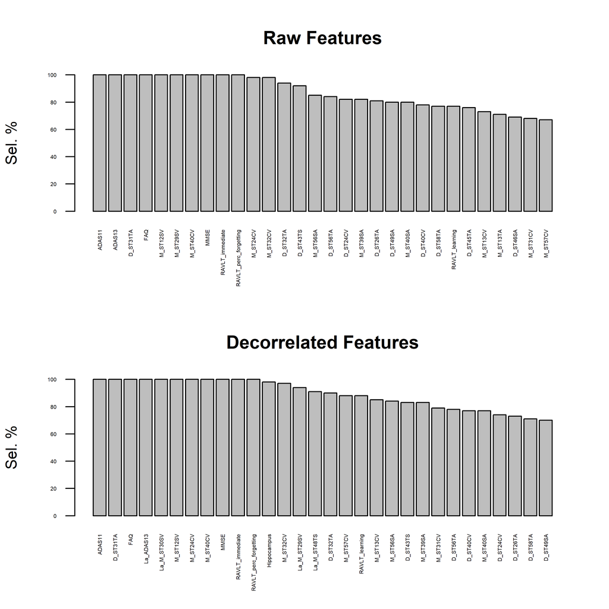

```r
par(mfrow=c(2,1),cex=0.9,cex.axis=0.8)

rawtopf <- cvRaw$featureFrequency/repetitions
crawtopf <- rawtopf

if (length(rawtopf) > 30)
{
  rawtopf <- rawtopf[1:30]
}
barplot(100*rawtopf,las=2,main="Raw Features",ylim=c(0,100.0),cex.names = 0.35,cex.axis = 0.35,ylab="Sel. %")

detopf <- cvDe$featureFrequency/repetitions
cdetopf <- detopf
names(cdetopf) <- str_remove_all(names(cdetopf),"Ba_")
names(cdetopf) <- str_remove_all(names(cdetopf),"La_")
if (length(detopf) > 30)
{
  detopf <- detopf[1:30]
}

barplot(100*detopf,las=2,main="Decorrelated Features",ylim=c(0,100.0),cex.names = 0.35,cex.axis = 0.35,ylab="Sel. %")
```

```r
par(op)
```

### 2.6.1 Final Table

```r
unlistdecorr <- selectedlist
names(unlistdecorr) <- NULL
unlistdecorr <- unique(names(unlist(unlistdecorr)))

finalTableDe <- univarDe$orderframe[deNames_in_dc,univariate_columns]

finalTableOr <- univar$orderframe[unique(c(topfiveOrg,unlistdecorr,names(crawtopf)[1:2],names(cdetopf)[1:2])),univariate_columns]

finalTable <- rbind(finalTableOr,finalTableDe)

deFromula <- character(length(theDeFormulas))
names(deFromula) <- names(theDeFormulas)

for (dx in names(deFromula))
{
  coef <- theDeFormulas[[dx]]
  cname <- names(theDeFormulas[[dx]])
  names(cname) <- cname
  for (cf in names(coef))
  {
    if (cf != dx)
    {
      if (coef[cf]>0)
      {
        deFromula[dx] <- paste(deFromula[dx],
                               sprintf("+ %5.3f*%s",coef[cf],cname[cf]))
      }
      else
      {
        deFromula[dx] <- paste(deFromula[dx],
                               sprintf("%5.3f*%s",coef[cf],cname[cf]))
      }
    }
  }
}

orgnamez <- rownames(finalTable)
orgnamez <- str_remove_all(orgnamez,"Ba_")
orgnamez <- str_remove_all(orgnamez,"La_")
finalTable$uAUC <- univar$orderframe[orgnamez,"ROCAUC"]
finalTable$raw_Freq <- crawtopf[orgnamez]
finalTable$La_Freq <- cdetopf[orgnamez]
finalTable$DecorFormula <- deFromula[rownames(finalTable)]
fscores <- attr(DEdataframe,"fscore")
finalTable$fscores <- fscores[rownames(finalTable)]

finalTable <- finalTable[order(-finalTable$ROCAUC),]

pander::pander(finalTable)
```

|  | caseMean | caseStd | controlMean | controlStd | controlKSP | ROCAUC | WilcoxRes.p | FRes.p | uAUC | raw_Freq | La_Freq | DecorFormula | fscores |
| --- | --- | --- | --- | --- | --- | --- | --- | --- | --- | --- | --- | --- | --- |
| **ADAS13** | 20.761066 | 6.169227 | 14.009106 | 5.789699 | 3.55e-02 | 0.788 | 1.26e-35 | 0.00e+00 | 0.788 | 1.00 | 1.00 | NA | NA |
| **ADAS11** | 12.863525 | 4.561284 | 8.715528 | 3.849783 | 2.64e-03 | 0.761 | 2.80e-31 | 0.00e+00 | 0.761 | 1.00 | 1.00 | NA | 1 |
| **FAQ** | 5.463115 | 4.902619 | 1.926606 | 2.982574 | 0.00e+00 | 0.756 | 8.02e-32 | 0.00e+00 | 0.756 | 1.00 | 1.00 | NA | NA |
| **M_ST40CV** | 0.179856 | 0.008748 | 0.187527 | 0.007629 | 2.82e-01 | 0.750 | 2.50e-28 | 0.00e+00 | 0.750 | 1.00 | 1.00 | NA | NA |
| **M_ST29SV** | 0.125302 | 0.007075 | 0.132097 | 0.007502 | 5.81e-01 | 0.745 | 1.38e-25 | 0.00e+00 | 0.745 | 1.00 | 0.94 | NA | NA |
| **Hippocampus** | 0.158226 | 0.008856 | 0.166444 | 0.009452 | 4.43e-01 | 0.737 | 4.57e-24 | 0.00e+00 | 0.737 | NA | 0.98 | NA | 1 |
| **M_ST13TA** | 0.019203 | 0.001934 | 0.020626 | 0.001767 | 4.30e-01 | 0.715 | 2.80e-21 | 0.00e+00 | 0.715 | 0.71 | 0.29 | NA | NA |
| **M_ST40TA** | 0.022408 | 0.002148 | 0.023875 | 0.001739 | 4.42e-01 | 0.703 | 4.02e-20 | 0.00e+00 | 0.703 | 0.01 | 0.01 | NA | NA |
| **M_ST31TA** | 0.018741 | 0.001851 | 0.020062 | 0.001711 | 2.69e-01 | 0.703 | 3.04e-19 | 0.00e+00 | 0.703 | NA | 0.03 | NA | 6 |
| **M_ST32TA** | 0.022480 | 0.002000 | 0.023790 | 0.001761 | 7.81e-01 | 0.698 | 2.70e-18 | 0.00e+00 | 0.698 | 0.16 | 0.44 | NA | 2 |
| **M_ST30SV** | 0.088728 | 0.018183 | 0.076594 | 0.018707 | 1.29e-01 | 0.681 | 6.11e-15 | 1.44e-15 | 0.681 | 0.08 | 1.00 | NA | NA |
| **M_ST129CV** | 0.155851 | 0.007028 | 0.160443 | 0.007074 | 6.68e-01 | 0.680 | 4.28e-15 | 4.44e-16 | 0.680 | NA | 0.67 | NA | NA |
| **La_M_ST30SV** | -0.005805 | 0.010722 | -0.012683 | 0.011405 | 9.50e-01 | 0.669 | 2.80e-13 | 4.90e-14 | 0.681 | 0.08 | 1.00 | -0.319*Ventricles + 1.000*M_ST30SV | -1 |
| **M_ST54CV** | 0.108225 | 0.006256 | 0.112004 | 0.006832 | 4.52e-01 | 0.661 | 5.35e-12 | 2.43e-12 | 0.661 | 0.11 | 0.25 | NA | NA |
| **M_ST49TA** | 0.015503 | 0.001572 | 0.016377 | 0.001490 | 5.10e-01 | 0.657 | 1.86e-12 | 4.87e-13 | 0.657 | NA | 0.24 | NA | NA |
| **M_ST129SA** | 0.392360 | 0.018424 | 0.402860 | 0.019476 | 5.79e-01 | 0.654 | 5.34e-11 | 2.47e-12 | 0.654 | 0.08 | 0.05 | NA | 1 |
| **M_ST129TA** | 0.024281 | 0.001934 | 0.025250 | 0.001873 | 9.44e-01 | 0.643 | 1.30e-10 | 7.15e-11 | 0.643 | NA | NA | NA | 1 |
| **M_ST43TA** | 0.018217 | 0.002016 | 0.019169 | 0.001894 | 1.69e-01 | 0.637 | 4.83e-10 | 4.73e-10 | 0.637 | NA | NA | NA | 2 |
| **M_ST48TA** | 0.012306 | 0.001169 | 0.012899 | 0.001281 | 2.39e-01 | 0.634 | 1.52e-08 | 1.14e-09 | 0.634 | NA | NA | NA | 1 |
| **La_ADAS13** | 2.672258 | 2.070109 | 1.753250 | 1.988479 | 4.56e-01 | 0.631 | 3.10e-09 | 5.40e-09 | 0.788 | 1.00 | 1.00 | -1.406*ADAS11 + 1.000*ADAS13 | -1 |
| **M_ST54SA** | 0.217624 | 0.018512 | 0.226585 | 0.020147 | 6.54e-01 | 0.630 | 2.63e-08 | 1.17e-08 | 0.630 | 0.05 | 0.01 | NA | 1 |
| **La_M_ST129CV** | -0.013097 | 0.001467 | -0.013683 | 0.001674 | 3.37e-01 | 0.617 | 2.94e-07 | 5.86e-06 | 0.680 | NA | 0.67 | -2.057*M_ST129TA -0.303*M_ST129SA + 1.000*M_ST129CV | -2 |
| **Ventricles** | 0.296627 | 0.045981 | 0.280136 | 0.049256 | 3.12e-01 | 0.603 | 3.27e-06 | 1.59e-05 | 0.603 | NA | NA | NA | 2 |
| **La_M_ST54CV** | 0.011825 | 0.002041 | 0.012472 | 0.001867 | 1.24e-01 | 0.602 | 6.81e-06 | 7.32e-06 | 0.661 | 0.11 | 0.25 | -1.480*M_ST54TA -0.279*M_ST54SA + 1.000*M_ST54CV | -2 |
| **La_M_ST49TA** | 0.003820 | 0.000874 | 0.004083 | 0.000939 | 9.32e-01 | 0.587 | 1.14e-04 | 1.93e-04 | 0.657 | NA | 0.24 | -0.641*M_ST43TA + 1.000*M_ST49TA | -1 |
| **D_ST31TA** | 0.000942 | 0.000723 | 0.000736 | 0.000559 | 5.22e-05 | 0.578 | 1.03e-05 | 1.65e-05 | 0.578 | 1.00 | 1.00 | NA | NA |
| **La_M_ST40TA** | 0.002058 | 0.001045 | 0.002339 | 0.000925 | 3.17e-01 | 0.577 | 1.95e-04 | 1.14e-04 | 0.703 | 0.01 | 0.01 | -0.905*M_ST32TA + 1.000*M_ST40TA | -1 |
| **M_ST48TS** | 0.003407 | 0.000614 | 0.003546 | 0.000584 | 2.48e-01 | 0.572 | 3.09e-03 | 1.26e-03 | 0.572 | NA | 0.91 | NA | NA |
| **La_M_ST13TA** | 0.002904 | 0.001152 | 0.003177 | 0.001018 | 5.41e-01 | 0.572 | 1.08e-03 | 4.69e-04 | 0.715 | 0.71 | 0.29 | + 1.000*M_ST13TA -0.870*M_ST31TA | -1 |
| **La_M_ST48TS** | -0.001382 | 0.000370 | -0.001473 | 0.000310 | 1.03e-01 | 0.565 | 3.50e-04 | 2.87e-04 | 0.572 | NA | 0.91 | -0.389*M_ST48TA + 1.000*M_ST48TS | -1 |
| **M_ST54TA** | 0.024122 | 0.002397 | 0.024550 | 0.002324 | 6.29e-01 | 0.556 | 1.51e-02 | 1.01e-02 | 0.556 | NA | NA | NA | 1 |
| **La_M_ST29SV** | -0.000393 | 0.001452 | -0.000126 | 0.000549 | 0.00e+00 | 0.525 | 1.71e-07 | 4.43e-04 | 0.745 | 1.00 | 0.94 | -0.794*Hippocampus + 1.000*M_ST29SV | -1 |